# Identifying H. m. rosina Scaffolds Using Hmel2.5

Krista Pipho

2024-07-19

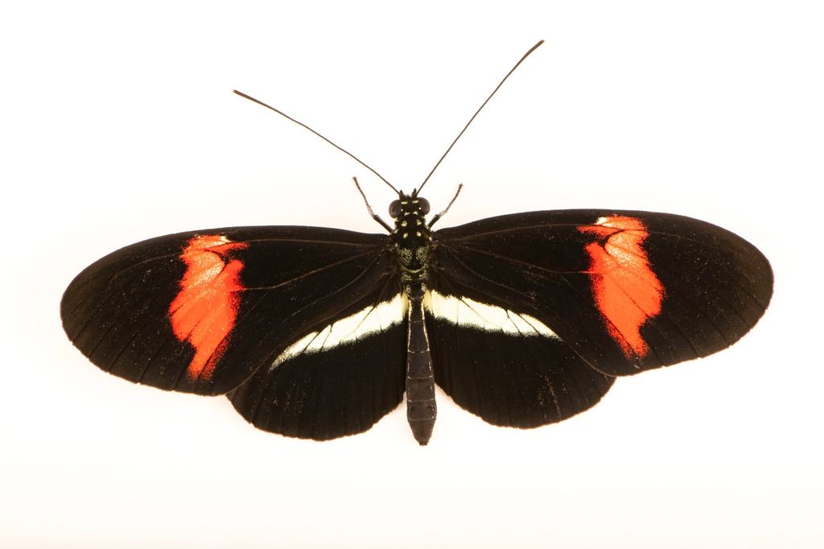

Heliconius melpomene rosina

```r
library(tidyverse)
library(kableExtra) # Formatting Tables
library(pheatmap) # Plotting Heatmap
library(jsonlite) # Querying Orthodb
```

### Introduction

In November of 2023 the Wray Lab sent a Heliconius melpomene rosina pupal sample to the Duke genomics core facility for Pacbio HIFI sequencing. The resulting reads were fed into the HIFIasm software (Cheng et al. 2021) to create a de novo assembled reference genome(below left)(Gurevich et al. 2013). The new genome’s completeness was preliminary assessed by using BUSCO docker (Simão et al. 2015) to search for a set of conserved lepadopteran genes in the published H. melpomene 2.5 genome (Davey et al. 2016) as well as our new assembly. The resulting H. m. rosina BUSCO values are very high, and slightly better than those for Hmel2.5 (below right). Here we use the conserved genes found by BUSCO to identify the relationship between scaffolds in Hmel2.5 and H. m. rosina. In this analysis scaffolds containing many of the same BUSCO annotations are presumed to be homologous chromosomes.

| QUAST Statistics | Scaffolds | L50 | L90 |
| --- | --- | --- | --- |
| Hmel2.5 | 332 | 9 | 19 |
| H. m. rosina | 120 | 9 | 20 |

| % of 5286 Conserved Genes | Complete | Duplicated | Missing |
| --- | --- | --- | --- |
| Hmel2.5 | 98.7 | 0.4 | 1.0 |
| H. m. rosina | 98.9 | 0.3 | 0.9 |

### Scaffold Overview

```r
hmr_scaffolds <- read.csv("hmr.p_ctg.fa.fai",sep="\t", header=FALSE, skip = 2) %>% select(V1, V2)
hed_scaffolds <- read.csv("hed.p_ctg.fa.fai",sep="\t", header=FALSE, skip = 2) %>% select(V1, V2)
hmel2.5_scaffolds <- read.csv("Heliconius_melpomene_melpomene_Hmel2.5.scaffolds.fa.fai",sep="\t", header=FALSE, skip = 2) %>% select(V1, V2)


hmr_scaffolds$assembly <- "hmr"
hmel2.5_scaffolds$assembly <- "hmel2.5"
combined_scaffold_table <- rbind(hmr_scaffolds,hmel2.5_scaffolds)
```

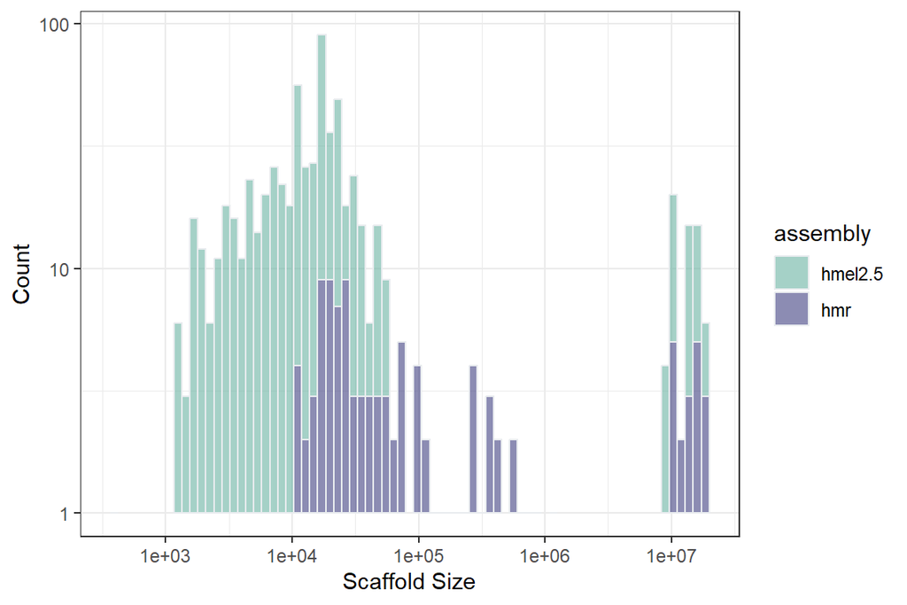

```r
ggplot(combined_scaffold_table, aes(x = V2, fill=assembly)) +
 geom_histogram( color="#e9ecef", alpha=0.6, bins = 75) +
    scale_fill_manual(values=c("#69b3a2", "#404080")) +
    scale_x_log10() +
  scale_y_log10() +
    theme_bw() +
  ylab("Count") +
  xlab("Scaffold Size")
```

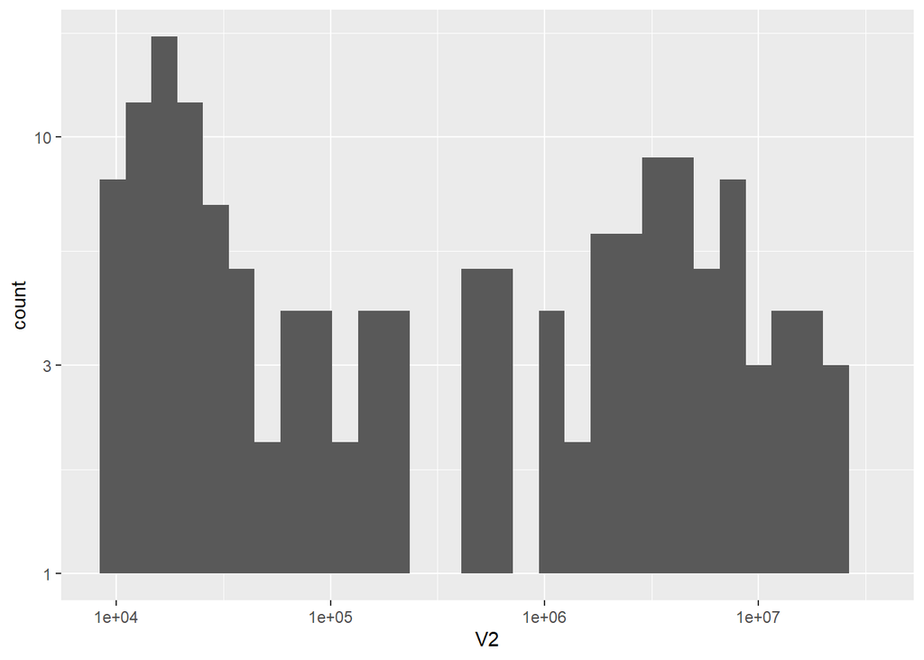

```r
ggplot(hed_scaffolds, aes(x = V2)) +
  geom_histogram() +
    scale_x_log10() +
  scale_y_log10()
```

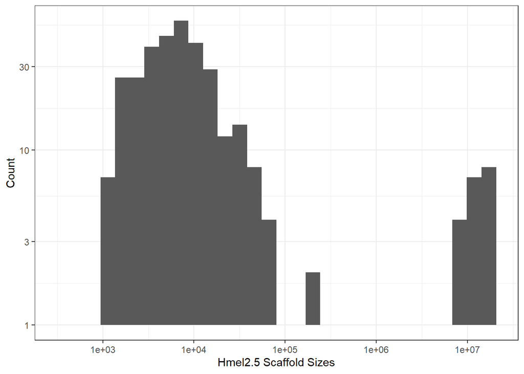

```r
ggplot(hmel2.5_scaffolds, aes(x = V2)) +
  geom_histogram() +
    scale_x_log10() +
  scale_y_log10() +
    theme_bw() +
  ylab("Count") +
  xlab("Hmel2.5 Scaffold Sizes")
```

### BUSCO Overview

Here I load data generated by BUSCO, which contains BUSCO IDs of conserved genes along with scaffold and base pair locations of the gene in the assembly. See below a summary visual of BUSCO gene number per scaffold. Empty category names correspond to BUSCO genes not found anywhere in the assemblies.

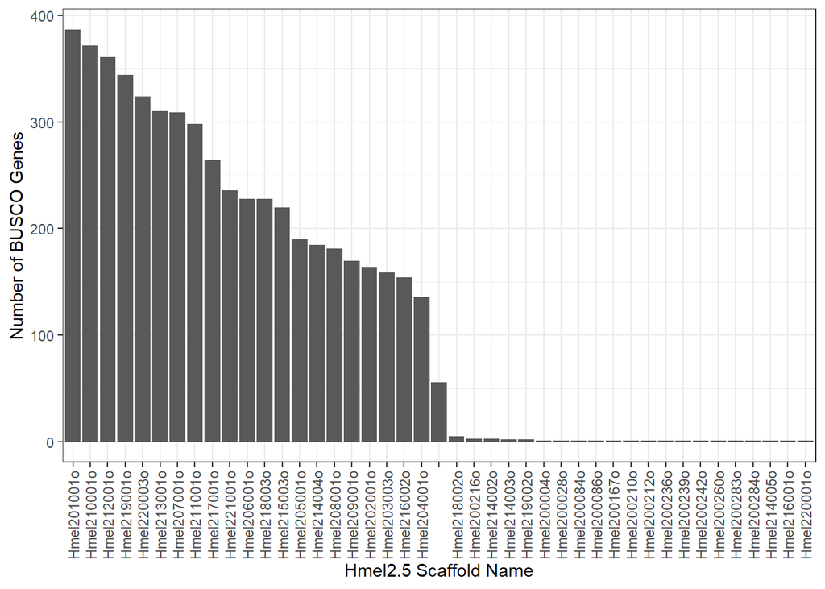

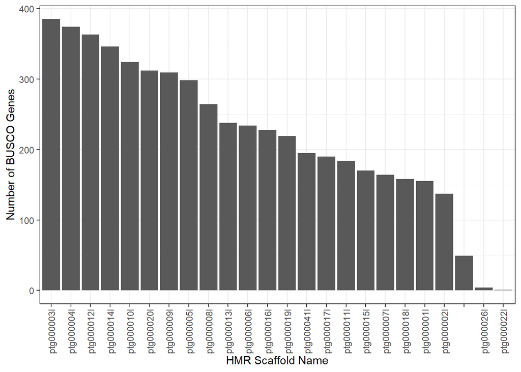

```r
#These tables must have the headers fixed with underscores

### Open Hmel2.5 BUSCO results
melpomene_busco <- read.csv("hmel2.5_full_table.tsv",sep="\t", header=TRUE, skip = 2)

# Group results by scaffold name, and count genes per scaffold
# Empty row name corresponds to BUSCO genes that were not found in the assembly
melpomene_busco_table <- melpomene_busco %>%
 group_by(Sequence) %>% summarise(n = n()) %>% arrange(n) %>% as_tibble()

# Plot number of BUSCO genes per scaffold
ggplot(melpomene_busco_table, aes(x=reorder(Sequence, -n), y=n)) +
  geom_bar(stat = "identity") +
  theme_bw() +
  theme(axis.text.x = element_text(angle = 90, vjust = 0.5, hjust=1)) +
  xlab("Hmel2.5 Scaffold Name") +
  ylab("Number of BUSCO Genes")

### Open hmr BUSCO results
our_busco <- read.csv("hmr_full_table.tsv",sep="\t", header=TRUE, skip = 2)

# Group results by scaffold name, and count genes per scaffold
# Empty row name corresponds to BUSCO genes that were not found in the assembly
our_busco_table <- our_busco %>%
 group_by(Sequence) %>% summarise(n = n()) %>% arrange(n) %>% as_tibble()

# Plot number of BUSCO genes per scaffold
ggplot(our_busco_table, aes(x=reorder(Sequence, -n), y=n)) +
  geom_bar(stat = "identity") +
  theme_bw() +
  theme(axis.text.x = element_text(angle = 90, vjust = 0.5, hjust=1))+
  xlab("HMR Scaffold Name") +
  ylab("Number of BUSCO Genes")
```

Next I extract lists of BUSCO genes present on each scaffold, then make every possible pairwise overlap comparison between Hmel2.5 and Hmr scaffolds. Overlaps of at least one gene but fewer than 8 genes represent small deviations between assemblies, including some genes that are moved, duplicated, or found in only one assembly. These are stored for further analysis. Overlaps of 8 or more genes are used to assign homology between scaffolds in the two assemblies. A list of homologous assemblies is printed below, accompanied by a heatmap visual of gene overlap.

```r
# Extract the BUSCO gene names per scaffold (Hmel2.5)
melpomene_busco$Sequence <- factor(melpomene_busco$Sequence)
melpomene_busco2 <-melpomene_busco %>%
 group_by(melpomene_busco$Sequence) %>% summarize(TheList = list(Busco_id)) %>% select(TheList)

melpomeneList <- melpomene_busco2[[1]]
names(melpomeneList) <- levels(melpomene_busco$Sequence)


# Extract the BUSCO gene names per scaffold (Hmr)
our_busco$Sequence <- factor(our_busco$Sequence)
our_busco2 <-our_busco %>%
 group_by(our_busco$Sequence) %>% summarize(TheList = list(Busco_id)) %>% select(TheList)

rosinaList <- our_busco2[[1]]
names(rosinaList) <- levels(our_busco$Sequence)

# Build an empty matrix to hold all pairwise overlap comparisons
x  <- matrix(NA_real_, length(melpomeneList), length(rosinaList))
rownames(x) <- names(melpomeneList)
colnames(x) <- names(rosinaList)

found.or.moved.genes <- c() # Makes list of genes present in small overlaps

# Loop through all pairs of hmel2.5 x hmr scaffolds and quantify busco gene overlap
for (i in seq_along(melpomeneList)){
  for (j in seq_along(rosinaList)){

      # Creates a list of overlapped genes
      gene.list <- intersect(unlist(melpomeneList[i]), unlist(rosinaList[j]))

      # Creates a list of genes that represent small, unexpected overlaps (genes only in one assembly or assembled onto different scaffolds)
      if (length(gene.list) > 0 && length(gene.list) < 8) { found.or.moved.genes <- c(found.or.moved.genes,gene.list)
      #cat(names(rosinaList[j]), "\t", names(melpomeneList[i]), "\t", length(gene.list), "\n")
      }

      # Creates and print out a list of scaffold pairs with 8 or more BUSCO gene overlaps
      if (length(gene.list) > 7) {cat(names(rosinaList[j]), "\t", names(melpomeneList[i]), "\t", length(gene.list), "\n")
        }
      x[i,j] <- length(gene.list)
    }
}
```

```
##           42
## ptg000003l    Hmel201001o     385
## ptg000007l    Hmel202001o     164
## ptg000018l    Hmel203003o     157
## ptg000002l    Hmel204001o     136
## ptg000017l    Hmel205001o     190
## ptg000016l    Hmel206001o     228
## ptg000009l    Hmel207001o     308
## ptg000011l    Hmel208001o     180
## ptg000015l    Hmel209001o     168
## ptg000004l    Hmel210001o     371
## ptg000005l    Hmel211001o     296
## ptg000012l    Hmel212001o     360
## ptg000020l    Hmel213001o     309
## ptg000041l    Hmel214004o     185
## ptg000019l    Hmel215003o     215
## ptg000001l    Hmel216002o     154
## ptg000008l    Hmel217001o     264
## ptg000006l    Hmel218003o     228
## ptg000014l    Hmel219001o     343
## ptg000010l    Hmel220003o     322
## ptg000013l    Hmel221001o     235
```

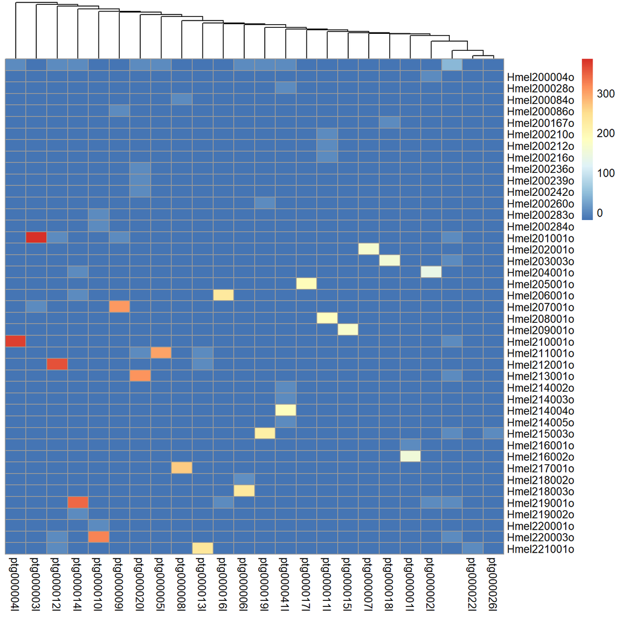

```r
# Creates a modified overlap matrix and plots the result
x_adj = x
x_adj[x_adj == 0] <- -20 #  Changed to better visualize small non-zero overlap numbers
pheatmap::pheatmap(x_adj,cluster_rows = FALSE)
```

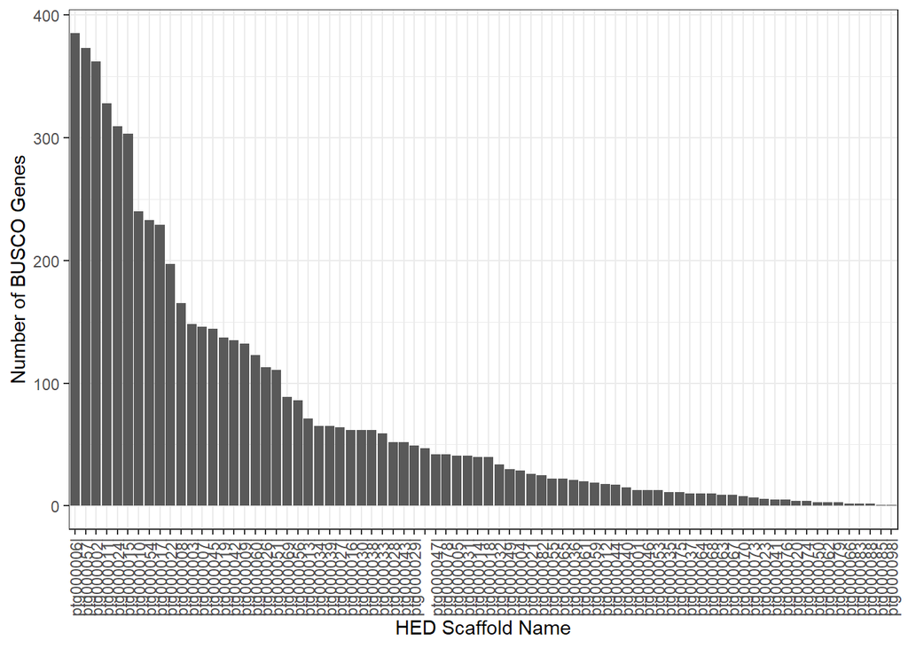

```r
### Open hed BUSCO results
hed_busco <- read.csv("hed_full_table.tsv",sep="\t", header=TRUE, skip = 2)

# Group results by scaffold name, and count genes per scaffold
# Empty row name corresponds to BUSCO genes that were not found in the assembly
hed_busco_table <- hed_busco %>%
 group_by(Sequence) %>% summarise(n = n()) %>% arrange(n) %>% as_tibble()

# Plot number of BUSCO genes per scaffold
ggplot(hed_busco_table, aes(x=reorder(Sequence, -n), y=n)) +
  geom_bar(stat = "identity") +
  theme_bw() +
  theme(axis.text.x = element_text(angle = 90, vjust = 0.5, hjust=1))+
  xlab("HED Scaffold Name") +
  ylab("Number of BUSCO Genes")
```

```r
# Extract the BUSCO gene names per scaffold (Hmr)
hed_busco$Sequence <- factor(hed_busco$Sequence)
hed_busco2 <-hed_busco %>%
 group_by(hed_busco$Sequence) %>% summarize(TheList = list(Busco_id)) %>% select(TheList)

rosinaList <- hed_busco2[[1]]
names(rosinaList) <- levels(hed_busco$Sequence)

# Build an empty matrix to hold all pairwise overlap comparisons
x  <- matrix(NA_real_, length(melpomeneList), length(rosinaList))
rownames(x) <- names(melpomeneList)
colnames(x) <- names(rosinaList)

found.or.moved.genes <- c() # Makes list of genes present in small overlaps

# Loop through all pairs of hmel2.5 x hmr scaffolds and quantify busco gene overlap
for (i in seq_along(melpomeneList)){
  for (j in seq_along(rosinaList)){

      # Creates a list of overlapped genes
      gene.list <- intersect(unlist(melpomeneList[i]), unlist(rosinaList[j]))

      # Creates a list of genes that represent small, unexpected overlaps (genes only in one assembly or assembled onto different scaffolds)
      if (length(gene.list) > 0 && length(gene.list) < 8) { found.or.moved.genes <- c(found.or.moved.genes,gene.list)
      #cat(names(rosinaList[j]), "\t", names(melpomeneList[i]), "\t", length(gene.list), "\n")
      }

      # Creates and print out a list of scaffold pairs with 8 or more BUSCO gene overlaps
      if (length(gene.list) > 7) {cat(names(rosinaList[j]), "\t", names(melpomeneList[i]), "\t", length(gene.list), "\n")
        }
      x[i,j] <- length(gene.list)
    }
}
```

```
##           35
## ptg000006l    Hmel201001o     385
## ptg000003l    Hmel202001o     148
## ptg000004l    Hmel202001o     29
## ptg000044l    Hmel202001o     17
## ptg000001l    Hmel203003o     13
## ptg000007l    Hmel203003o     145
## ptg000063l    Hmel203003o     9
## ptg000005l    Hmel204001o     39
## ptg000013l    Hmel204001o     69
## ptg000014l    Hmel204001o     39
## ptg000028l    Hmel204001o     52
## ptg000029l    Hmel204001o     49
## ptg000035l    Hmel204001o     11
## ptg000011l    Hmel205001o     63
## ptg000012l    Hmel205001o     18
## ptg000032l    Hmel205001o     34
## ptg000034l    Hmel205001o     65
## ptg000036l    Hmel205001o     21
## ptg000069l    Hmel205001o     89
## ptg000078l    Hmel205001o     34
## ptg000017l    Hmel206001o     227
## ptg000024l    Hmel207001o     307
## ptg000018l    Hmel208001o     40
## ptg000031l    Hmel208001o     41
## ptg000038l    Hmel208001o     59
## ptg000047l    Hmel208001o     40
## ptg000064l    Hmel208001o     10
## ptg000070l    Hmel208001o     8
## ptg000026l    Hmel209001o     94
## ptg000030l    Hmel209001o     61
## ptg000043l    Hmel209001o     38
## ptg000046l    Hmel209001o     13
## ptg000057l    Hmel210001o     370
## ptg000021l    Hmel211001o     26
## ptg000027l    Hmel211001o     64
## ptg000042l    Hmel211001o     126
## ptg000051l    Hmel211001o     110
## ptg000078l    Hmel211001o     8
## ptg000002l    Hmel212001o     360
```

[output cut: 14 more lines]

```
## ptg000043l    Hmel216002o     14
## ptg000065l    Hmel216002o     21
## ptg000068l    Hmel216002o     10
## ptg000016l    Hmel217001o     60
## ptg000022l    Hmel217001o     196
## ptg000053l    Hmel217001o     13
## ptg000008l    Hmel218003o     165
## ptg000033l    Hmel218003o     52
## ptg000075l    Hmel218003o     11
## ptg000010l    Hmel219001o     238
## ptg000055l    Hmel219001o     20
## ptg000056l    Hmel219001o     86
## ptg000015l    Hmel220003o     301
## ptg000061l    Hmel220003o     20
## ptg000054l    Hmel221001o     231
```

[figure not shown]

[output not shown]

[output not shown]

```r
# Creates a modified overlap matrix and plots the result
x_adj = x
x_adj[x_adj == 0] <- -20 #  Changed to better visualize small non-zero overlap numbers
pheatmap::pheatmap(x_adj,cluster_rows = FALSE)
```

```r
# Example print command to get BUSCO IDs for any scaffold
print(melpomeneList[7])
```

```
## $Hmel200210o
## [1] "550at7088"
```

```r
print(rosinaList)
```

[output not shown]

[output cut: 1352 more lines]

```r
busco_ids <- found.or.moved.genes
names(busco_ids) <- busco_ids # fix for map_df .id issue

# a tibble of profiles associated with each busco_id
busco_ipr <- map_df(busco_ids, .id="busco_id",  function(busco_id){

  # map the BUSCO ID to OrthoDB group ID
  query <- read_json(paste0("http://v101.orthodb.org/search?query=", busco_id))
  odb_id <- query$data[1]

  # get all info on the orthogroup via quiery
  odb_info <- read_json(paste0("http://v101.orthodb.org/group?id=", odb_id),
  simplifyVector = TRUE)

  # return the info table
  odb_info$data$interpro_domains
})

busco_ipr %>% select(busco_id, description) %>% tibble()
```

```
## # A tibble: 242 x 2
##    busco_id    description
##    <chr>       <chr>
##  1 3497at7088  Major facilitator superfamily
##  2 3497at7088  Major facilitator,  sugar transporter-like
##  3 5251at7088  Protein kinase domain
##  4 5251at7088  Serine-threonine/tyrosine-protein kinase, catalytic domain
##  5 11462at7088 TATA-box binding protein
##  6 13200at7088 DnaJ domain
##  7 12547at7088 GINS subunit, domain A
##  8 13687at7088 Zinc finger, double-stranded RNA binding
##  9 10238at7088 Tetraspanin/Peripherin
## 10 16088at7088 Brain protein I3
## # i 232 more rows
```

## References

Cheng, Haoyu, Gregory T. Concepcion, Xiaowen Feng, Haowen Zhang, and Heng Li. 2021. “Haplotype-Resolved de Novo Assembly Using Phased Assembly Graphs with Hifiasm.” *Nature Methods 2021 18:2* 18 (February): 170–75. https://doi.org/10.1038/s41592-020-01056-5.

Davey, John W., Mathieu Chouteau, Sarah L. Barker, Luana Maroja, Simon W. Baxter, Fraser Simpson, Mathieu Joron, James Mallet, Kanchon K. Dasmahapatra, and Chris D. Jiggins. 2016. “Major Improvements to the Heliconius Melpomene Genome Assembly Used to Confirm 10 Chromosome Fusion Events in 6 Million Years of Butterfly Evolution.” *G3: Genes, Genomes, Genetics* 6 (March): 695–708. https://doi.org/10.1534/G3.115.023655/-/DC1.

Gurevich, Alexey, Vladislav Saveliev, Nikolay Vyahhi, and Glenn Tesler. 2013. “QUAST: Quality Assessment Tool for Genome Assemblies.” *Bioinformatics (Oxford, England)* 29 (April): 1072–75. https://doi.org/10.1093/BIOINFORMATICS/BTT086.

Simão, Felipe A., Robert M. Waterhouse, Panagiotis Ioannidis, Evgenia V. Kriventseva, and Evgeny M. Zdobnov. 2015. “BUSCO: Assessing Genome Assembly and Annotation Completeness with Single-Copy Orthologs.” *Bioinformatics* 31 (October): 3210–12. https://doi.org/10.1093/BIOINFORMATICS/BTV351.

.